# Création de cartes choroplèthes avec {ggplot2}

# 1 Introduction

Une carte choroplèthe est une carte thématique dans laquelle les régions géographiques sont ombrées ou modélisées proportionnellement à la valeur d’une variable représentée. Cette variable peut être un indicateur épidémiologique tel que la prévalence ou le taux de mortalité d’une maladie. Les cartes choroplèthes sont particulièrement utiles pour visualiser les motifs spatiaux et les variations entre différentes régions.

Les composants essentiels d’une carte choroplèthe incluent :

**Régions géographiques** : Ce sont les zones qui seront représentées sur la carte, telles que les pays, les états, les districts ou d’autres divisions géographiques.

**Valeurs des données** : Ce sont les valeurs associées à chaque région géographique qui seront représentées sur la carte, y compris la densité de population, la prévalence, l’incidence, le taux de mortalité, etc.

**Échelle de couleurs** : C’est la gamme de couleurs utilisée pour représenter les différentes valeurs des données. Typiquement, un gradient de couleurs est utilisé, avec des couleurs plus claires représentant des valeurs inférieures et des couleurs plus foncées représentant des valeurs supérieures.

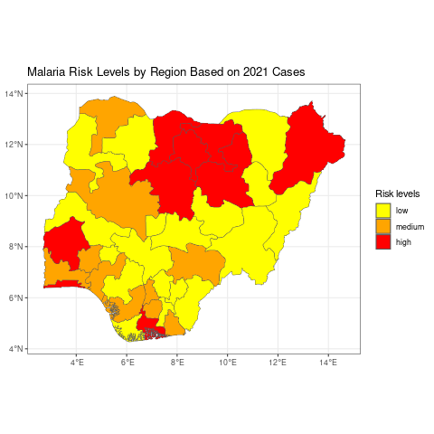

Les cartes choroplèthes offrent :

- Des visuels clairs mettant en évidence les tendances des données spatiales.
- Des conceptions intuitives compréhensibles sans expertise.

Cependant, elles présentent des défis :

- La classification des données et les choix de couleurs peuvent biaiser les apparences.
- Les régions plus grandes pourraient dominer, causant un biais visuel.

Dans la section suivante, vous apprendrez à créer une carte choroplèthe en utilisant le package {ggplot2} dans R.

# 2 Objectifs d’apprentissage

1. **Cartes choroplèthes avec {ggplot2} :**
   - Maîtriser les fonctions `ggplot()` et `geom_sf()` pour la visualisation des cartes.
2. **Appariement des données avec des polygones :**
   - Obtenir des limites et des données liées aux maladies.
   - Combiner les données en fonction des niveaux administratifs.
3. **Techniques d’échelle de couleurs :**
   - Implémenter des échelles de couleurs pour les types de données continues et discrètes.
4. **Facettes pour la visualisation des cartes :**
   - Utiliser `facet_wrap()` et `facet_grid()` pour créer des petites cartes multiples.

# 3 Charger les packages nécessaires

Ce morceau de code ci-dessous montre comment charger les paquets nécessaires en utilisant `p_load()` du package {pacman}. S’ils ne sont pas installés, il installe le paquet avant de le charger.

```r
# Charger les paquets nécessaires

# Utiliser pacman pour charger plusieurs paquets ; il les installera s'ils ne sont pas déjà installés
pacman::p_load(tidyverse,  # pour la manipulation et la visualisation des données
               here,       # pour les chemins de fichiers relatifs au projet
               sf)         # pour les données spatiales

# Désactiver la notation scientifique pour des affichages numériques plus clairs
options(scipen=10000)
```

# 4 Préparation des données

Avant de créer une carte choroplèthe, il est essentiel de préparer les données. Les données doivent contenir les régions géographiques et les valeurs que vous souhaitez visualiser.

Dans cette section, vous passerez en revue le processus de préparation des données, qui comprend les étapes suivantes :

Maintenant, passons en détail à chaque étape !

## 4.1 Étape 1 : Importer les données de polygones

Les polygones sont des formes fermées avec trois côtés ou plus. Dans les données spatiales, les polygones sont utilisés pour représenter des zones telles que la limite d’une ville, d’un lac ou de tout type d’utilisation des terres. Ils sont essentiels dans les systèmes d’information géographique (SIG) pour des tâches telles que la cartographie, l’analyse spatiale et la classification de l’occupation des terres.

Les fichiers de formes (shapefiles) sont un format courant pour stocker des données spatiales. Ils se composent d’au moins trois fichiers avec des extensions .shp (forme), .shx (index) et .dbf (données attributaires).

Dans R, vous pouvez charger des fichiers de formes en utilisant le package `sf`. Dans notre leçon d’aujourd’hui, nous travaillerons avec des données sur le paludisme provenant de la revue Epi du Nigeria (2022).

```r
# Lecture du fichier de formes
nga_adm1 <-
  sf::st_read(here::here("data/raw/NGA_adm_shapefile/NGA_adm1.shp"))
```

Les éléments importants de toute couche ggplot sont les mappings esthétiques `aes(x,y, …)` qui indiquent à ggplot où placer les objets graphiques.

Nous pouvons imaginer une carte comme un graphique avec toutes les fonctionnalités mappées sur un axe x et y. Tous les types de géométrie (`geom_`) dans ggplot comportent une sorte de mapping esthétique, et ceux-ci peuvent être déclarés au niveau du graphique, par exemple, `ggplot(data, aes(x = variable1, y = variable2))`, ou au niveau de chaque couche individuelle, par exemple, `geom_point(aes(color = variable3))`.

Ci-dessous, vous pouvez voir que `geom_sf()` est utilisé pour tracer les limites des différents états du Nigeria. De même, différentes couches peuvent être ajoutées par-dessus.

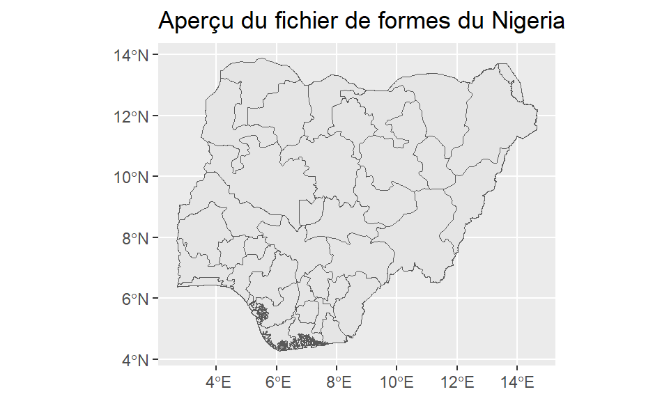

```r
ggplot()+
  geom_sf(data = nga_adm1)+
  labs(title = "Aperçu du fichier de formes du Nigeria")
```

Ici, nous lisons d’abord le fichier de formes du Nigeria en utilisant `sf::st_read()` puis nous le traçons en utilisant `ggplot`. La fonction `geom_sf()` est utilisée pour rendre les données spatiales, et `labs()` est utilisé pour ajouter un titre au graphique.

Comme le fichier de formes a été chargé en utilisant `sf::st_read()`, nous n’avons pas besoin de spécifier les noms des axes. En fait, les coordonnées sont stockées comme un objet multipolygone dans la variable géométrie, et `geom_sf()` les reconnaît automatiquement.

Pour les utilisateurs intéressés par l’accès aux données de limites infranationales dans R, il existe plusieurs packages disponibles sur GitHub qui facilitent ce processus :

- Le {rgeoboundaries} (https://github.com/wmgeolab/rgeoboundaries) récupère des données de [Geoboundaries](https://www.geoboundaries.org/), une base de données ouverte de limites administratives politiques.
- Le {rnaturalearth} (https://github.com/ropensci/rnaturalearth) récupère des données de [Natural Earth](https://www.naturalearthdata.com/), un ensemble de données cartographiques du domaine public.

## 4.2 Étape 2 : Importer les Données d’Attribut

Dans le contexte des cartes choroplèthes, les “données d’attribut” font référence aux informations quantitatives ou qualitatives qui seront utilisées pour colorer ou nuancer les différentes zones géographiques sur la carte. Par exemple, si vous avez une carte des régions d’un pays et souhaitez colorer chaque région en fonction de sa population, les données sur la population seraient considérées comme des données d’attribut.

Comme souligné ci-dessus, nous utiliserons le nombre de cas de paludisme signalés au Nigeria pour les années 2000, 2006, 2010, 2015 et 2021.

```r
# Lecture des données d'attribut
malaria_cases <- read_csv(here::here("data/malaria.csv"))
malaria_cases
```

| state_name | cases_2000 | cases_2006 | cases_2010 | cases_2015 | cases_2021 |
| --- | --- | --- | --- | --- | --- |
| Abia | 2425032 | 2845380 | 3165352 | 3616381 | 4243233 |
| Adamawa | 2677882 | 3178950 | 3564061 | 4111706 | 4881061 |
| Akwa Ibom | 3192785 | 3902051 | 4460413 | 5272028 | 6443191 |
| Anambra | 3539907 | 4177828 | 4665766 | 5356592 | 6321894 |
| Bauchi | 3807290 | 4653066 | 5318894 | 6286719 | 7683291 |
| Bayelsa | 1435848 | 1704515 | 1911007 | 2204647 | 2617167 |
| Benue | 3562357 | 4253641 | 4787510 | 5550036 | 6627034 |
| Borno | 3412933 | 4171104 | 4767966 | 5635544 | 6887460 |
| Cross River | 2436993 | 2892988 | 3243456 | 3741838 | 4441986 |
| Delta | 3404253 | 4112445 | 4664648 | 5460310 | 6596226 |

[output cut: 27 more lines]